# Week 1 Notes: Practical Machine Learning

## Process:

question -> input data -> features -> algorithm -> parameters -> evaluation

**Features matter!**

**Properties of good features**

- Lead to data compression
- Retain relevant information
- Are created based on expert application knowledge

**Common mistakes**

- Trying to automate feature selection
- Not paying attention to data-specific quirks
- Throwing away information unnecessarily

**Algorithms matter less than you’d think**

**Issues to consider:**

Interpretable

Simple

Accurate

Fast

Scalable

## In sample and out sample error

**In Sample Error**: The error rate you get on the same data set you used to build your predictor. Sometimes called resubstitution error.

**Out of Sample Error**: The error rate you get on a new data set. Sometimes called generalization error.

**Key ideas**

1. Out of sample error is what you care about
2. In sample error $<$ out of sample error
3. The reason is overfitting
- Matching your algorithm to the data you have
- Data have two parts
- Signal
- Noise
- The goal of a predictor is to find signal
- You can always design a perfect in-sample predictor
- You capture both signal + noise when you do that
- Predictor won’t perform as well on new samples

## Prediction Study Design

1. Define your error rate
2. Split data into:
- Training, Testing, Validation (optional)
3. On the training set pick features
- Use cross-validation
4. On the training set pick prediction function
- Use cross-validation
6. If no validation
- Apply 1x to test set
7. If validation
- Apply to test set and refine
- Apply 1x to validation

http://www2.research.att.com/~volinsky/papers/ASAStatComp.pdf

## Rules of thumb for prediction study design

- If you have a large sample size
- 60% training
- 20% test
- 20% validation
- If you have a medium sample size
- 60% training
- 40% testing
- If you have a small sample size
- Do cross validation
- Report caveat of small sample size

## Basic terms

In general, **Positive** = identified and **negative** = rejected. Therefore:

**True positive** = correctly identified

**False positive** = incorrectly identified

**True negative** = correctly rejected

**False negative** = incorrectly rejected

** Summary **

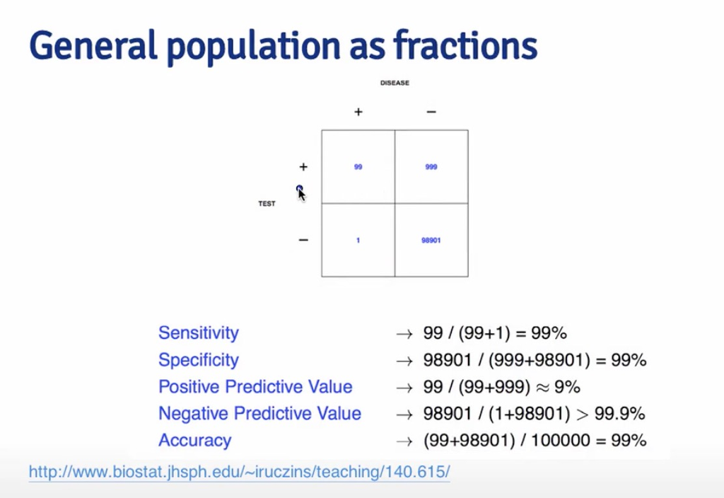

## For continuous data

**Mean squared error (MSE)**:

$$\frac{1}{n} \sum_{i=1}^n (Prediction_i - Truth_i)^2$$

**Root mean squared error (RMSE)**:

$$\sqrt{\frac{1}{n} \sum_{i=1}^n(Prediction_i - Truth_i)^2}$$
## Cross Validation:

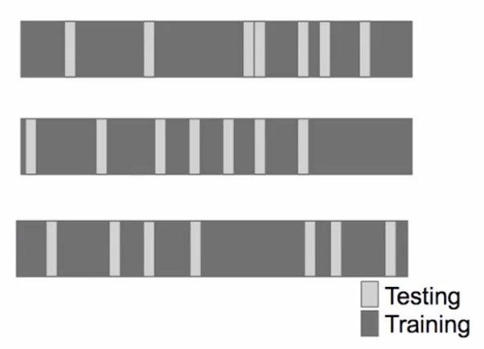

**Key idea**

1. Accuracy on the training set (resubstitution accuracy) is optimistic
2. A better estimate comes from an independent set (test set accuracy)
3. But we can’t use the test set when building the model or it becomes part of the training set
4. So we estimate the test set accuracy with the training set.

*Approach*:

1. Use the training set
2. Split it into training/test sets
3. Build a model on the training set
4. Evaluate on the test set
5. Repeat and average the estimated errors

*Used for*:

1. Picking variables to include in a model
2. Picking the type of prediction function to use
3. Picking the parameters in the prediction function
4. Comparing different predictors

## K-Fold

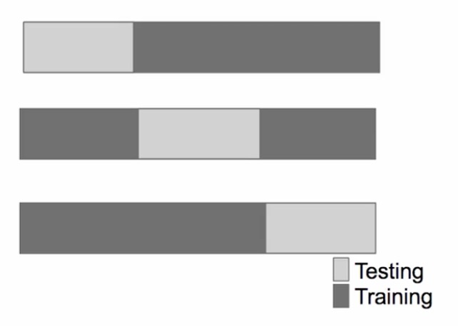